# STK4900 - Statistical Methods and Applications

Olivia Beyer Bruvik

6/11/2021

# Lecture 5

## Topics

1. Checking model assumptions (2)
2. Selection of predictors (23)
3. Generalized Additive Models (GAM) (19)
4. High dimensional regression (33)

https://www.uio.no/studier/emner/matnat/math/STK4900/v21/lectures/lecture5.pdf

## Checking model assumptions

### Assumptions for linear regression

$$y_i = \eta_i + \epsilon_i$$

Plots of the residuals may be used to check:

1. Linearity
2. Constant variance
3. Normal errors

#### Linearity

$$\eta_i = \beta_0 + \beta_1x_{1i} + \beta_2x_{2i} + ... + \beta_px_{pi}$$
If the model is linear in all predictors, except the j-th:
$$\eta_i = \beta_0 + \beta_1x_{1i} + ... + \beta_{j-1}x_{j-1,i} + f_j(x_{ji})+\beta_{j+1}x_{j+1,i} ... + \beta_px_{pi}$$

We can estimate the function $f_j(x)$ with a CPR plot.

##### Check of linearity

Component-plus-residual (CPR) plot of the partial residuals, $\hat{\beta}_jx_{ji} + r_i$, versus the values of the predictor, $(x_{ji})$.

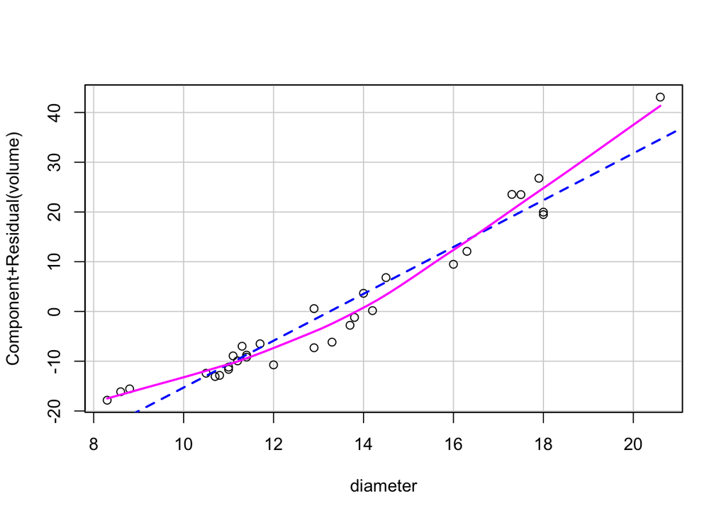

```r
### Fit a model w/ volume as outcome and diameter and height as predictors, and make a CPR plot for diameter:
fit.both=lm(volume~diameter+height, data=trees)

## The plot indicates that a second degree polynomial may be more appropriate:
crPlots(fit.both, terms=~diameter)
```

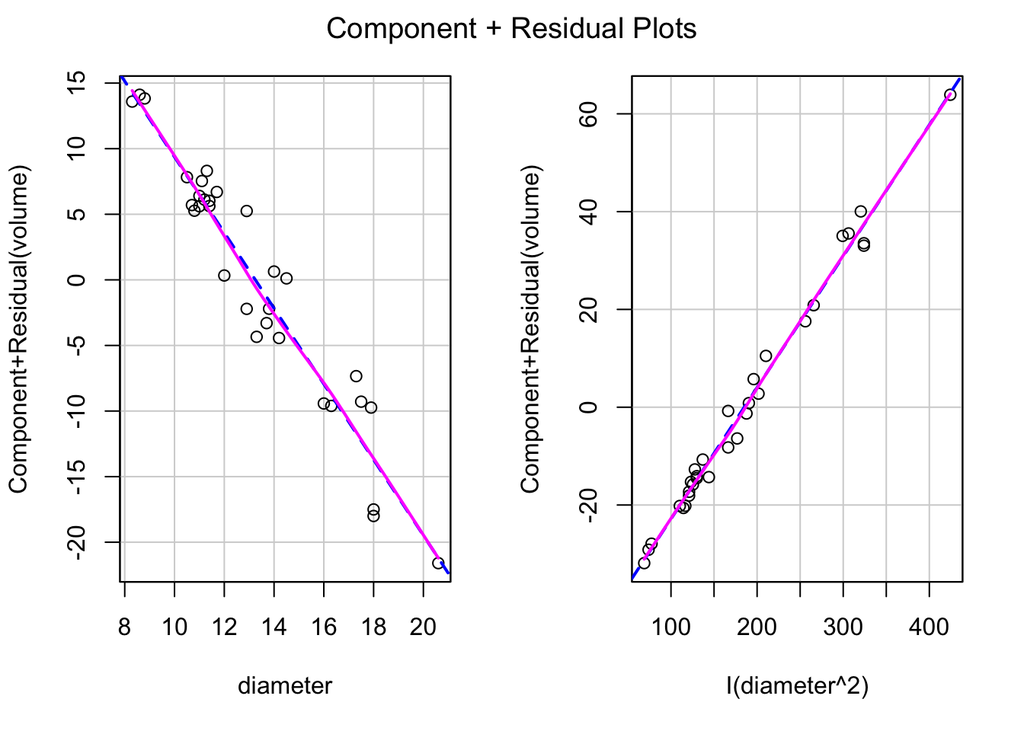

```r
### Fit a model that also has a second degree term for diameter, and make a CPR plots for diameter and diameter^2:
fit.sq=lm(volume~diameter+I(diameter^2)+height, data=trees)

## The plot indicate that the linearity assumption is reasonable both for diameter and diameter^2 (ie. linearity in the parameters)
crPlots(fit.sq,terms=~diameter+I(diameter^2))
```

##### The importance of model assumptions

Non-linearity leads to wrong specification of the systematic part of the model, which can result in:

1. Effect of a predictor may be wrongly estimated
2. Important predictor not detected
3. Serious nonlinearity jeopardizes analysis

##### Model misfit and possible improvements

1. Transform $x_{ji}$, e.g. $log(x_{ji})$
2. Transform $y_{ji}$, e.g. $log(y_{ji})$
3. Include second order term(s) and/or interaction(s)
4. GAM

#### Constant variance (homoscedasticity)

$$Var(\epsilon_i) = \sigma_\epsilon^2 \quad for \space all \space i$$
There should be no systematic patterns in the residuals.

##### Check of homoscedasticity

A plot of the residuals versus the fitted (or predicted) values.

Fan like shape: the variances increase/decrease with expected outcome.

NB. Don’t trust the fitted lines where there is little data.

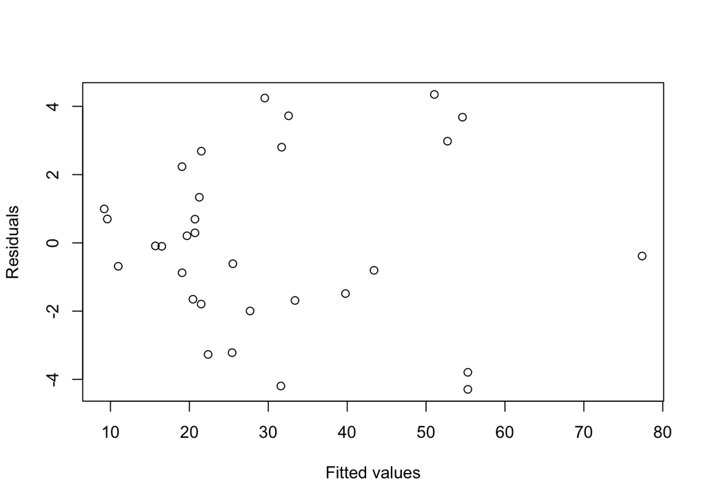

```r
fit.sq=lm(volume~diameter+I(diameter^2)+height, data=trees)

## Reasonable, but some indication of increasing variances
plot(fit.sq$fit, fit.sq$res, xlab="Fitted values", ylab="Residuals")
```

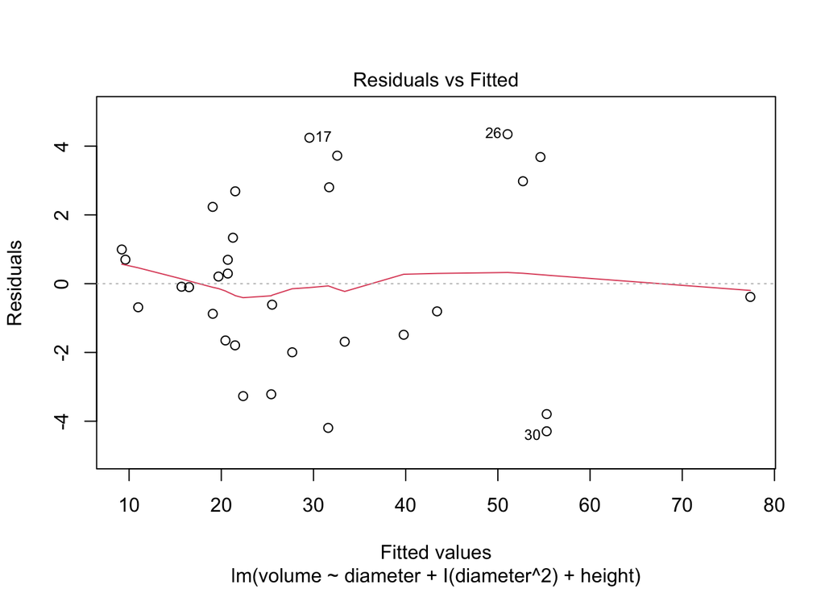

```r
## Added line used to detect pattern in the residuals due to non-linearities
plot(fit.sq,1)
```

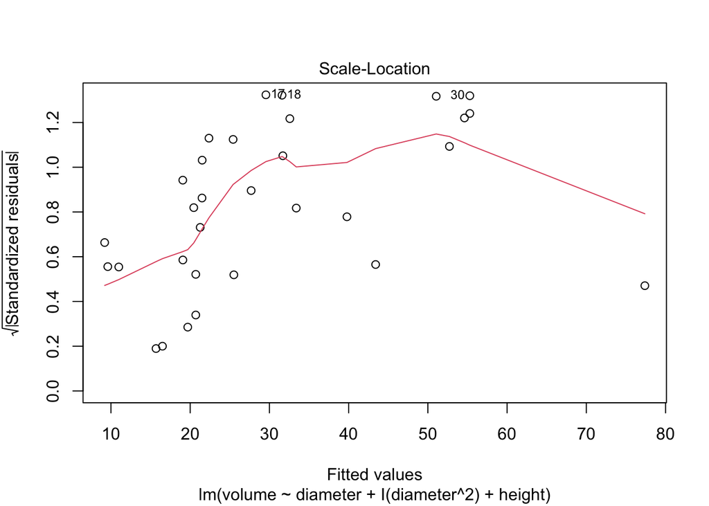

```r
## Added line used to detect increasing variance (or standard deviation)
plot(fit.sq,3)
```

##### The importance of model assumptions

If the variances aren’t equal and/or the errors are correlated:

1. Flawed prediction intervals
2. The estimates of the $\beta_j's$ will be unbiased
3. Wrongly estimated standard errors
4. Flawed CI and p-values

##### Model misfit and possible improvements

1. Transform $x_{ji}$, e.g. $log(x_{ji})$ or $\sqrt{x_{ji}}$
2. Use weighted least-squares
3. GAM

#### Normally distributed errors

The residuals should behave as a sample from a normal distribution with mean zero:

$$\epsilon_i \sim N(0,\sigma_\epsilon^2)$$
##### Check of normality

1. Histogram of residuals
2. Boxplot of residuals
3. Normal Q-Q plot of residuals

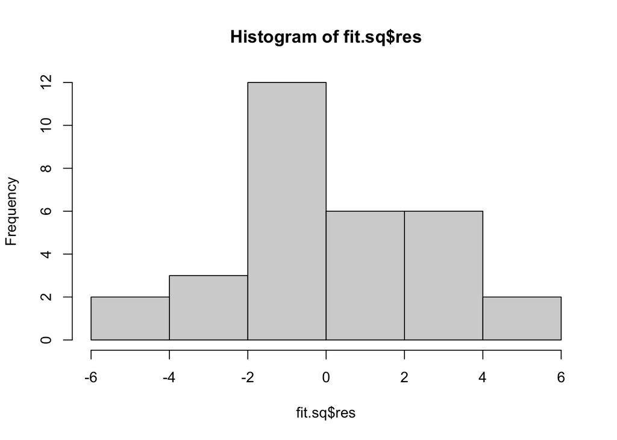

```r
hist(fit.sq$res)
```

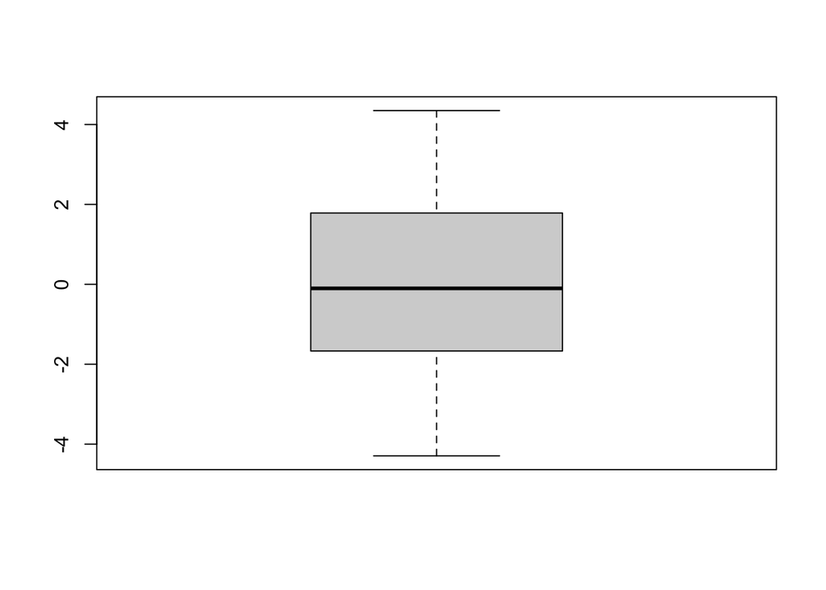

```r
boxplot(fit.sq$res)
```

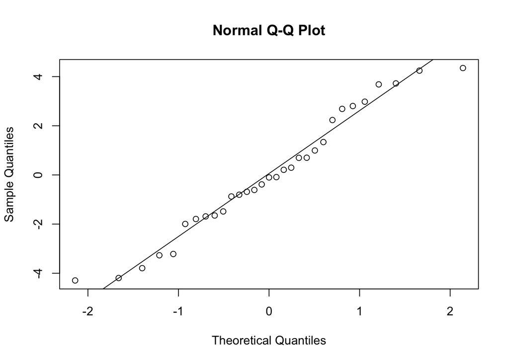

```r
## The Q-Q plot should be close to a straight line if the residuals are normally distributed.
qqnorm(fit.sq$res); qqline(fit.sq$res) ## Alternative: plot(fit.sq,2)
```

##### The importance of model assumptions

If normality not present, but other assumptions true: 1. Valid estimates of standard errors 1. Test statistics are not t- and F-distributed for small n 1. The distributional assumptions are not critical

##### Model misfit and possible improvements

1. Transform $y_i$
2. Bootstrap
3. Ignore problem for large n

#### Influential observations

It’s useful to inspect observations that have a large influence on the estimates.  
A measure for the influence of an observation is the change in the estimate(s) when the model is fitted leaving out the observation:

```r
# fit=lm(erosion~water)
#summary(fit)
# dfbeta(fit)

## dfbetas(fit) with an s gives the standardized dfbetas that may be more appropriate for multiple linear regression when the predictors are on different scales
# dfbetas(fit)
```

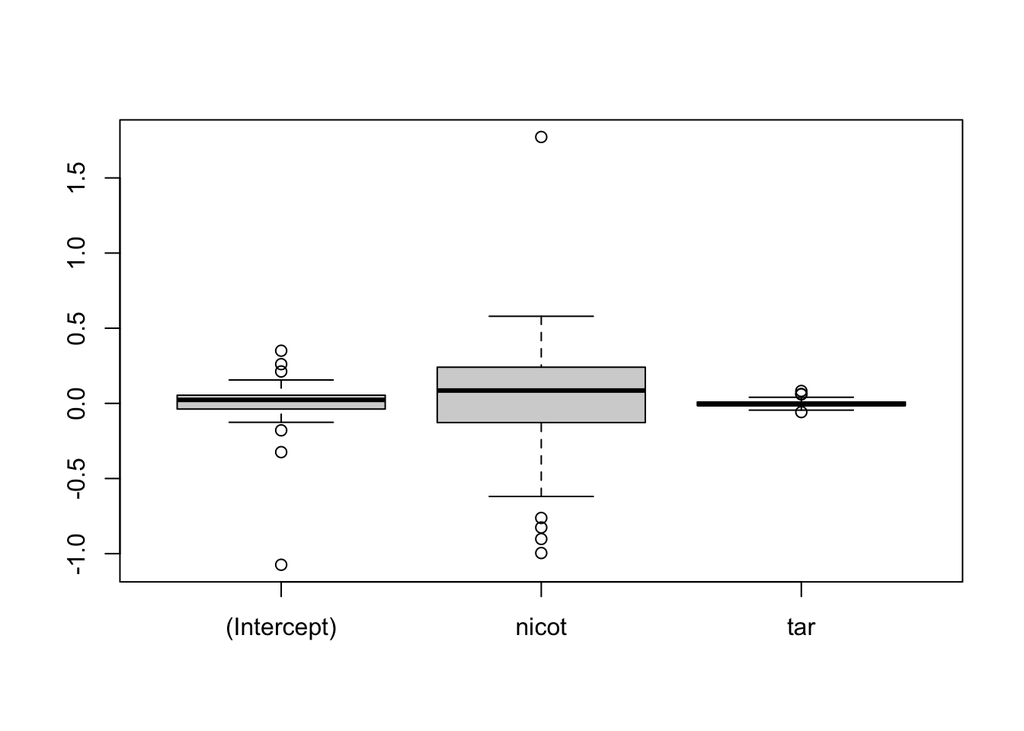

```r
fit.cig=lm(co~nicot+tar,data=cigarettes)
boxplot(dfbeta(fit.cig))
```

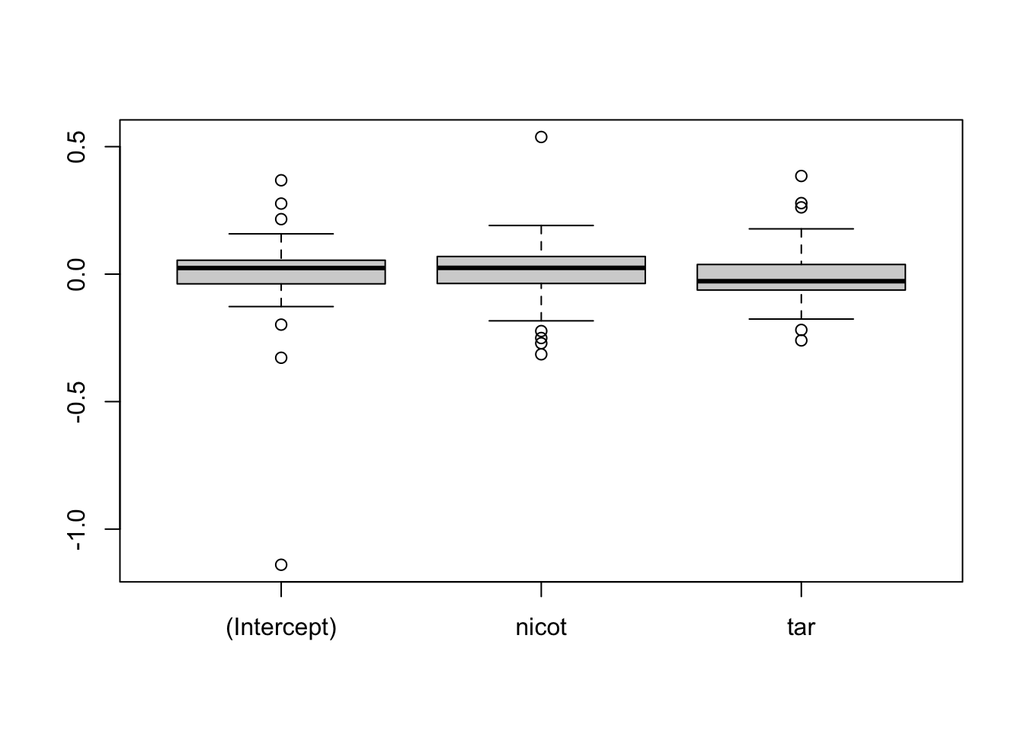

```r
boxplot(dfbetas(fit.cig))
```

##### The importance of model assumptions

- A few influential observations may have large effects on the estimates.
- Critical for conclusions on the relations btw covariates and response.

##### Model misfit and possible improvements

1. Check the coding of the observations
2. Validate the estimates by running the regression without the influential observations

#### Uncorrelated errors

$$Cov(\epsilon_i,\epsilon_j) = 0 \quad for \space all \space i \neq j$$

The importance of model assumptions Model misfit and possible improvements

## Generalized Additive Models (GAM)

1. Extension of linear model
2. CI estimation for estimated curves
3. Test whether there is significant non-linearity in the models

### Model

Assume a general functional dependency on the covariates:

$$\eta_i = \beta_0 + f_1(x_{1i}) + f_2(x_{2i}) + ... + f_p(x_{pi})$$
### Assumptions 1. The functions are smooth: * continuous * have derivatives

```r
library(gam)
```

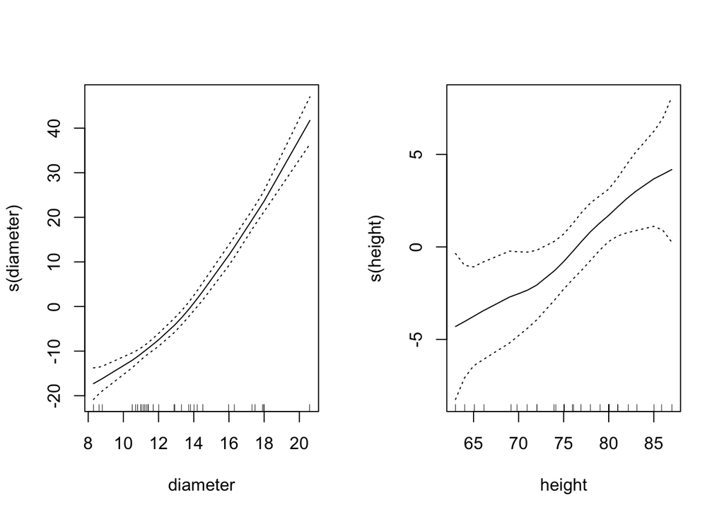

```r
fit.gam.both=gam(volume~s(diameter)+s(height), data=trees)
par(mfrow=c(1,2))
plot(fit.gam.both,se=T)
```

```r
## force the dependency on height to be linear:
fit.gam.dia=gam(volume~s(diameter)+height, data=trees)
```

### Analysis of plots

diameter-function (diameter - s(diameter)):  
Forcing a straight line within the confidence limits impossible $\rightarrow$ significant non-linearity.

height-function (height - s(height)):  
Forcing a straight line within the confidence limits possible $\rightarrow$ no important non-linearity.

### Anova table

```r
fit.gam.dia=gam(volume~s(diameter)+height, data=trees)
anova(fit.both,fit.gam.dia,fit.gam.both)
```

```
## Analysis of Variance Table
##
## Model 1: volume ~ diameter + height
## Model 2: volume ~ s(diameter) + height
## Model 3: volume ~ s(diameter) + s(height)
##   Res.Df    RSS     Df Sum of Sq       F    Pr(>F)
## 1     28 421.92
## 2     25 180.56 3.0000   241.358 10.1298 0.0002172 ***
## 3     22 174.73 2.9999     5.836  0.2449 0.8640161
## ---
## Signif. codes:  0 '***' 0.001 '**' 0.01 '*' 0.05 '.' 0.1 ' ' 1
```

Analysis:

- non-linearity for diameter is significant
- there’s no reason to include a non-linear term for height.

## Selection of predictors

### Objectives:

1. Study one predictor while adjusting for others
2. Identify important predictors for an outcome
3. Predict the outcome for a new unit where only the values of the predictors are available

### Strategies to decide which sub-models to consider

#### Forward selection

1. Fit all *p* models with only one predictor
2. Choose highest-contributing predictor
3. Run *p-1* regressions with this predictor and another
4. Choose the model that “fits” best
5. Continue adding predictors until “no improvement”

#### Stepwise regression

Forward regression, but supplement step 4. with the deletion of predictors that no longer contribute.

#### Backward selection

1. Fit the model with all *p* predictors
2. Compare the model with all predictors with the *p* different models where one predictor has been left out
3. Leave out the “least important predictor”
4. Compare the model obtained with the *p-1* different models where one predictor has been left out
5. Leave out the “least important predictor”
6. Continue until a model is obtained that only contains the “important” predictors

### Criteria for inclusion / exclusion

Possibilities for inclusion of predictors:

P-values

- 5% cutoff often used
- suitable when the object is to study the effect of one predictor, or
- to identify important predictors for an outcome

Ordinary $R^2$

- Draw-back: will always increase when predictors are added.

Adjusted $R^2$

- penalizes including more predictors
- May be used to select predictors as it will have a maximum $R^2$ over the models considered
- Drawback: observations are used twice (estimate the $\beta_j's$ and evaluate the predictions of $y_i's$).

Cross-validated $R^2$

- Cross validation: stimate the regression model without using the observation $y_i$ and predict $\hat{y}_i^{(-i)}$, $y_i$ using the obtained estimates
- May be used to select predictors
- Will often give smaller models than $R_{adj}^2$.

## High dimensional regression

For data with more covariates than observations ($p > n$).

For p <n, in Ordinary Least Squares Regression, we minimize the MSE so that:

$$\hat{\beta} = argmin_{\beta}(y-X\beta)^2$$

### Lasso regression (L1 penalty)

$$\hat{\beta} = argmin_{\beta}(y-X\beta)^2 + \lambda||
\beta||_1$$

Variable selection:

- Leads to shrinkage of the coefficients
- Zeros out the coefficients of the unimpotant variables
- The size of $\lambda$ determines the amount of zero coefficients (may be chosed via K-fold cross-validation)

$$PRSS_y^{lasso}(\beta) = \sum_{i=1}^n(y_i-\beta_0-\sum_{j=1}^px_{ij}\beta_j)^2 + \lambda\sum_{j=1}^p{|\beta_j|}$$

#### Assumptions

Sparsity: only a few of the p covariates matter

```r
library(glmnet)
```

```r
## Gaussian family because of the continuous response and normal noise
## Alpha = 0 is ridge regression
#cv.fit.lasso=cv.glmnet(x,y,family="gaussian",alpha=1)

## Find lamba value that minimizes the CV-curve
#lambda.min=cv.fit.lasso$lambda.min

## Get the estimated coefficients for lambda.min
#beta.lasso=coef(cv.fit.lasso, s=lambda.min)
```

### Ridge regression (L2 penalty)

$$\hat{\beta} = argmin_{\beta}(y-X\beta)^2 + \lambda||
\beta||_2^2$$

No variable selection:

- shrinks the coefficients:
  - introduces bias
  - reduces variance of the estimators

$$PRSS_y^{ridge}(\beta) = \sum_{i=1}^n(y_i-\beta_0-\sum_{j=1}^px_{ij}\beta_j)^2 + \lambda\sum_{j=1}^p{\beta_j^2}$$